# Forecasting Princples and Practice 2 (5-7)

## 3.4 X11 decomposition

Another popular method for decomposing quarterly and monthly data is the **X11 method** which originated in the US Census Bureau and Statistics Canada.

This method is based on classical decomposition, but includes many *extra steps and features* in order to overcome the drawbacks of classical decomposition that were discussed in the previous section. In particular, **trend-cycle estimates** are available for all observations including the end points, and the seasonal component is allowed to vary slowly over time. X11 also has some sophisticated methods for handling trading day variation, holiday effects and the effects of known predictors. It handles both additive and multiplicative decomposition. The process is entirely automatic and tends to be highly robust to outliers and level shifts in the time series.

The details of the X11 method are described in @Dagum2016. Here we will only demonstrate how to use the automatic procedure in R.

The X11 method is available using the `seas` function from the `seasonal` package for R.

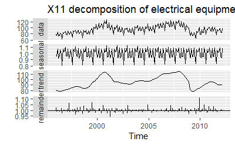

Compare this decomposition with the **STL decomposition** shown in Figure @ref(fig:elecequip-trend) and the classical decomposition shown in Figure @ref(fig:classical-elecequip). The X11 trend-cycle has captured the sudden fall in the data in early 2009 better than either of the other two methods, and the unusual observation at the end of 2009 is now more clearly seen in the remainder component.

Given the output from the `seas` function, `seasonal()` will extract the seasonal component, `trendcycle()` will extract the trend-cycle component, `remainder()` will extract the remainder component, and `seasadj()` will compute the seasonally adjusted time series.

For example, Figure @ref(fig:x11-seasadj) shows the trend-cycle component and the seasonally adjusted data, along with the original data.

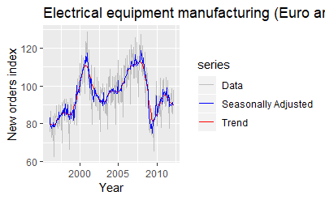

```r
autoplot(elecequip, series="Data") +
  forecast::autolayer(trendcycle(fit), series="Trend") +
  forecast::autolayer(seasadj(fit), series="Seasonally Adjusted") +
  xlab("Year") + ylab("New orders index") +
  ggtitle("Electrical equipment manufacturing (Euro area)") +
  scale_colour_manual(values=c("gray","blue","red"),
                     breaks=c("Data","Seasonally Adjusted","Trend"))
```

It can be useful to use seasonal plots and seasonal sub-series plots of the seasonal component. These help us to visualize the variation in the seasonal component over time. Figure @ref(fig:elecequip3) shows a seasonal sub-series plot of the seasonal component from Figure @ref(fig:x11). In this case, there are only very small changes over time.

[figure not shown]

```r
ggsubseriesplot(seasonal(fit)) + ylab("Seasonal")
```

## 3.5 SEATS decomposition

“SEATS” stands for **“Seasonal Extraction in ARIMA Time Series”** (ARIMA models are discussed in Chapter @ref(ch-arima)). This procedure was developed at the Bank of Spain, and is now widely used by government agencies around the world. The procedure works only with quarterly and monthly data. So seasonality of other kinds, such as daily data, or hourly data, or weekly data, require an alternative approach.

The details are beyond the scope of this book. However, a complete discussion of the method is available in @Dagum2016. Here we will only demonstrate how to use it via the `seasonal` package.

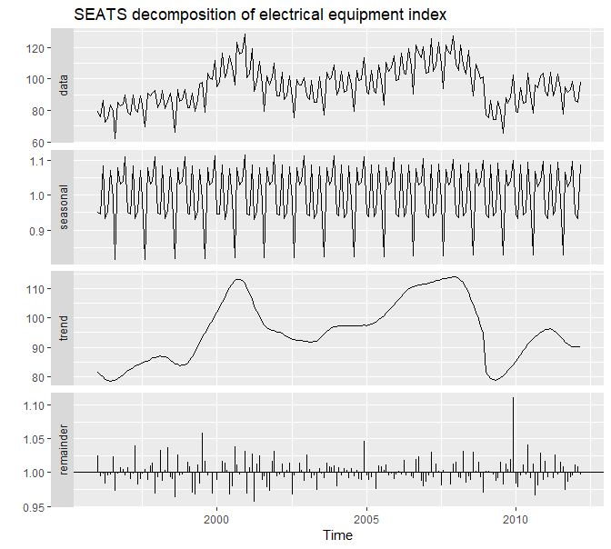

```r
library(seasonal)
elecequip %>% seas() %>%
  autoplot()+
  ggtitle("SEATS decomposition of electrical equipment index")
```

The result is quite similar to the X11 decomposition shown in Figure @ref(fig:x11).

As with the X11 method, we can use the `seasonal()`, `trendcycle()` and `remainder()` functions to extract the individual components, and `seasadj()` to compute the seasonally adjusted time series.

The `seasonal` package has many options for handling variations of X11 and SEATS. See [the package website](http://www.seasonal.website/seasonal.html) for a detailed introduction to the options and features available.

## 3.6 STL decomposition

**STL** is a very versatile and robust method for decomposing time series. STL is an acronym for “Seasonal and Trend decomposition using Loess”, while Loess is a method for estimating nonlinear relationships. The STL method was developed by @Cleveland1990.

STL has several advantages over the classical, SEATS and X-11 decomposition methods: - Unlike SEATS and X-11, STL will handle any type of seasonality, not only monthly and quarterly data. - The **seasonal component** is allowed to change over time, and the rate of change can be controlled by the user. - The **smoothness** of the trend-cycle can also be controlled by the user. - It can be robust to **outliers** (i.e., the user can specify a robust decomposition), so that occasional unusual observations will not affect the estimates of the trend-cycle and seasonal components. They will, however, affect the remainder component.

On the other hand, STL has some disadvantages. In particular, it does not handle trading day or calendar variation automatically, and it only provides facilities for additive decompositions.

It is possible to obtain a multiplicative decomposition by first taking logs of the data, then back-transforming the components. Decompositions between additive and multiplicative can be obtained using a Box-Cox transformation of the data with $0<\lambda<1$. A value of $\lambda=0$ corresponds to the multiplicative decomposition while $\lambda=1$ is equivalent to an additive decomposition.

The best way to begin learning how to use STL is to see some examples and experiment with the settings. Figure @ref(fig:elecequip-stl) showed an example of STL applied to the electrical equipment orders data. Figure @ref(fig:elecequip-stl2) shows an alternative STL decomposition where the trend-cycle is more flexible, the seasonal component does not change over time, and the robust option has been used. Here, it is more obvious that there has been a down-turn at the end of the series, and that the orders in 2009 were unusually low (corresponding to some large negative values in the remainder component).

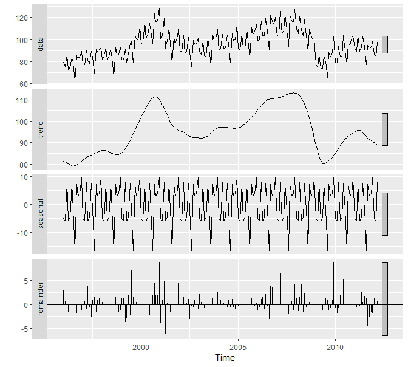

```r
elecequip %>%
  stl(t.window=13, s.window="periodic",robust = TRUE) %>%
  autoplot()
```

The two main parameters to be chosen when using STL are the trend-cycle window (`t.window`) and the seasonal window (`s.window`). These control how rapidly the trend-cycle and seasonal components can change. Smaller values allow for more rapid changes. Both `t.window` and `s.window` should be odd numbers and refer to the number of consecutive years to be used when estimating the trend-cycle and seasonal components respectively. The user must specify `s.window` as there is no default. Setting it to to be infinite is equivalent to forcing the seasonal component to be periodic (i.e., identical across years). Specifying `t.window` is optional, and a default value will be used if it is omitted.

As with the other decomposition methods discussed in this book, to obtain the separate components plotted in Figure @ref(fig:classical-elecequip), use the `seasonal()` function for the seasonal component, the `trendcycle()` function for trend-cycle component, and the `remainder()` function for the remainder component. The `seasadj()` function can be used to compute the seasonally adjusted series.